# Where to Find the Best Breakfast and Coffee in New Orleans

Yelp Open Dataset, MATH 167R Project 2 (Steps 1-7)

Published

November 15, 2026

## Research question

> **Where in New Orleans can someone find the best breakfast and coffee restaurants, and which geographic area is best for finding them?**

“Best” here means a high average Yelp rating *and* enough reviews that the rating can be trusted. I also adjust ratings for each reviewer’s usual scoring habits (Step 7).

```r
library(tidyverse)
library(sf)
library(tigris)
library(scales)
library(viridis)

options(tigris_use_cache = TRUE)
dir.create("figures", showWarnings = FALSE)
theme_set(theme_minimal(base_size = 12))
```

## Large-data management

The Yelp download is a 4.3 GB zip containing a 6.3 GB tar. The review file alone is 5.3 GB (about 7 million reviews) and the user file is 3.4 GB.

- **Disk:** I extracted only the business and review files from the tar (`tar -xf ... file1 file2`), not the check-in, tip and user files I did not need.
- **Memory:** Reading all of `yelp_academic_dataset_review.json` into R at once would need many GB of RAM. Instead `R/import.R` uses `jsonlite::stream_in()` with a `handler` that processes 50,000 reviews at a time and keeps only reviews for New Orleans restaurants. R never used more than about 1.2 GB, and the full import took about 6 minutes.
- **Columns:** only the columns needed for the analysis were kept (the business table drops attributes and hours).
- **Storage:** the filtered tables are saved as `xz`-compressed RDS files (`business_new_orleans.rds`, 117 KB; `reviews_new_orleans.rds`, 78 MB), after which the raw 10 GB of JSON, tar and zip can be deleted.
- **Sharing:** the raw files and the reviews RDS (which contains review text) are not committed to GitHub. Running `Rscript R/import.R` recreates them. The final analysis uses the complete set of New Orleans restaurants and all of their reviews, not a sample.

## Step 1-2: Import and filter to New Orleans restaurants

The import code is in `R/import.R`. A New Orleans restaurant is a Yelp business with `state == "LA"`, `city == "New Orleans"` and the text “Restaurants” in its `categories` field. Step 5 checks this label against an official boundary.

```r
restaurants <- readRDS("data/new_orleans/business_new_orleans.rds")
reviews <- readRDS("data/new_orleans/reviews_new_orleans.rds")

tibble(
  number_of_restaurants = nrow(restaurants),
  number_of_reviews = nrow(reviews),
  missing_coordinates = sum(is.na(restaurants$latitude) | is.na(restaurants$longitude)),
  missing_categories = sum(is.na(restaurants$categories))
)
```

```
# A tibble: 1 × 4
  number_of_restaurants number_of_reviews missing_coordinates missing_categories
                  <int>             <int>               <int>              <int>
1                  2259            476421                   0                  0
```

## Step 3: Choose related categories

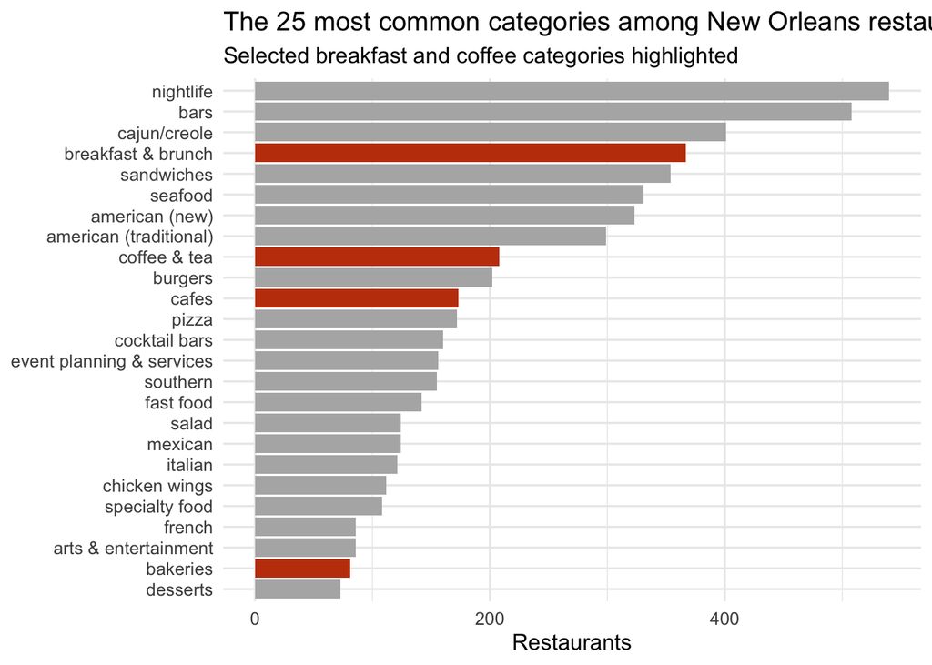

```r
restaurant_categories <- restaurants |>
  select(business_id, categories) |>
  separate_longer_delim(categories, delim = ",") |>
  transmute(business_id, category = str_to_lower(str_squish(categories)))

category_counts <- restaurant_categories |>
  filter(!category %in% c("restaurants", "food")) |>
  count(category, sort = TRUE)

selected_categories <- c("breakfast & brunch", "coffee & tea", "cafes", "bakeries")

category_counts |>
  slice_head(n = 25) |>
  mutate(selected = category %in% selected_categories) |>
  ggplot(aes(n, fct_reorder(category, n), fill = selected)) +
  geom_col() +
  scale_fill_manual(values = c(`TRUE` = "#c2410c", `FALSE` = "grey70"), guide = "none") +
  labs(
    title = "The 25 most common categories among New Orleans restaurants",
    subtitle = "Selected breakfast and coffee categories highlighted",
    x = "Restaurants", y = NULL
  )
```

```r
ggsave("figures/category_counts.png", width = 8, height = 6, dpi = 150, bg = "white")
```

I selected **breakfast & brunch, coffee & tea, cafes and bakeries**. They describe the same occasion: a morning meal or a coffee and pastry stop. I did not simply take the most common categories, since nightlife, bars and cajun/creole say nothing about mornings. To check that these categories belong together, I looked at which categories most often share a business with “breakfast & brunch”, and at the overlap between the selected categories.

```r
anchor <- restaurant_categories |>
  filter(category == "breakfast & brunch") |>
  distinct(business_id)

restaurant_categories |>
  semi_join(anchor, by = "business_id") |>
  filter(!category %in% c("restaurants", "food", "breakfast & brunch")) |>
  count(category, sort = TRUE, name = "shared_with_breakfast") |>
  slice_head(n = 12) |>
  knitr::kable(caption = "Categories that most often co-occur with Breakfast & Brunch")
```

Categories that most often co-occur with Breakfast & Brunch

| category | shared_with_breakfast |
| --- | --- |
| coffee & tea | 85 |
| sandwiches | 85 |
| american (new) | 83 |
| american (traditional) | 75 |
| nightlife | 75 |
| cajun/creole | 72 |
| bars | 71 |
| cafes | 65 |
| southern | 44 |
| burgers | 37 |
| seafood | 34 |
| bakeries | 32 |

```r
selected_long <- restaurant_categories |>
  filter(category %in% selected_categories) |>
  distinct(business_id, category)

inner_join(selected_long, selected_long, by = "business_id", relationship = "many-to-many") |>
  filter(category.x < category.y) |>
  count(category.x, category.y, name = "restaurants_in_both") |>
  arrange(desc(restaurants_in_both)) |>
  knitr::kable(caption = "Overlap between the selected categories")
```

Overlap between the selected categories

| category.x | category.y | restaurants_in_both |
| --- | --- | --- |
| breakfast & brunch | coffee & tea | 85 |
| cafes | coffee & tea | 75 |
| breakfast & brunch | cafes | 65 |
| bakeries | coffee & tea | 37 |
| bakeries | breakfast & brunch | 32 |
| bakeries | cafes | 16 |

Coffee & tea (85 restaurants), cafes (65) and bakeries (32) are all among the categories that most often appear alongside “breakfast & brunch”. The remaining common partners (sandwiches, American food, bars) are general restaurant types, not morning-specific, so I left them out. The four selected categories also overlap heavily with each other (for example 85 restaurants are both breakfast & brunch and coffee & tea), which supports treating them as one morning-food group.

**Inclusion rule:** a restaurant is included if it belongs to **at least one** of the four selected categories.

```r
selected_ids <- selected_long |> distinct(business_id)

selected_restaurants <- restaurants |>
  semi_join(selected_ids, by = "business_id") |>
  mutate(business_name = str_squish(name))

selected_reviews <- reviews |>
  semi_join(selected_restaurants, by = "business_id")

tibble(
  qualifying_restaurants = nrow(selected_restaurants),
  reviews_for_these_restaurants = nrow(selected_reviews)
)
```

```
# A tibble: 1 × 2
  qualifying_restaurants reviews_for_these_restaurants
                   <int>                         <int>
1                    575                        159552
```

## Step 4: Join businesses to reviews

Reviews were filtered to the selected restaurants *before* any joining (the `semi_join` above), so only reviews for relevant businesses are carried forward. The two tables share `business_id` (one restaurant, many reviews). The reviewer-level work comes in Step 7.

```r
selected_reviews |>
  count(business_id, name = "reviews_in_data") |>
  summarise(
    restaurants_with_reviews = n(),
    median_reviews = median(reviews_in_data),
    max_reviews = max(reviews_in_data)
  )
```

```
  restaurants_with_reviews median_reviews max_reviews
1                      575             76        7516
```

## Step 5: Add an official boundary with a spatial join

The Yelp `city` field is just a text label. I downloaded the Census place boundaries for Louisiana and tested which restaurant points actually fall inside the New Orleans boundary.

```r
louisiana_places <- places(state = "LA", cb = TRUE, year = 2024) |>
  st_transform(4326)

restaurant_points <- selected_restaurants |>
  st_as_sf(coords = c("longitude", "latitude"), crs = 4326, remove = FALSE)

restaurants_with_place <- restaurant_points |>
  st_join(louisiana_places |> select(place_name = NAME), join = st_within, left = TRUE)

restaurants_with_place |>
  st_drop_geometry() |>
  count(city, place_name, sort = TRUE) |>
  knitr::kable(caption = "Yelp city label vs. Census place containing the point")
```

Yelp city label vs. Census place containing the point

| city | place_name | n |
| --- | --- | --- |
| New Orleans | New Orleans | 564 |
| New Orleans | Elmwood | 2 |
| New Orleans | Harahan | 2 |
| New Orleans | Jefferson | 2 |
| New Orleans | Metairie | 2 |
| New Orleans | Terrytown | 2 |
| New Orleans | Kenner | 1 |

```r
mismatches <- restaurants_with_place |>
  st_drop_geometry() |>
  filter(is.na(place_name) | place_name != "New Orleans") |>
  select(business_name, address, postal_code, place_name)

mismatches |> knitr::kable(caption = "Restaurants labelled New Orleans by Yelp but outside the city boundary")
```

Restaurants labelled New Orleans by Yelp but outside the city boundary

| business_name | address | postal_code | place_name |
| --- | --- | --- | --- |
| Dots Diner | 2317 Jefferson Hwy | 70121 | Jefferson |
| Bagels & Bytes | 1001 Metairie Rd | 70005 | Metairie |
| Dejepe Bakery | 775 Berhman Hwy | 70056 | Terrytown |
| City Greens | 5161 Citrus Blvd | 70123 | Elmwood |
| Hickory Cafe & Grill | 1313 Hickory Ave | 70123 | Harahan |
| Pelican Cafe | 3901 Airline Dr | 70001 | Metairie |
| Wow Cafe | 5359 Mounes St | 70123 | Elmwood |
| Dunkin’ Donuts | 857 Terry Pkwy | 70056 | Terrytown |
| Breakfast Club Cafe | 8321 Jefferson Hwy | 70123 | Harahan |
| Haydel’s Bakery | 4037 Jefferson Hwy | 70121 | Jefferson |
| Le Petit Bistro |  | 70115 | Kenner |

All 11 mismatches are in neighboring Jefferson Parish communities (Metairie, Harahan, Kenner, Elmwood, Terrytown and Jefferson). They are labelled “New Orleans” by Yelp, most likely because of their postal address (several have 70121, 70123 or 70056 ZIPs that span the parish line). They are not typos, so I did not “fix” them. For the main analysis I keep only restaurants *inside* the official New Orleans boundary, so the question stays about the city and not its suburbs. One restaurant (Le Petit Bistro) has no street address and a point that falls in Kenner despite a 70115 ZIP, so its coordinates look wrong.

```r
new_orleans_boundary <- louisiana_places |> filter(NAME == "New Orleans")

in_city <- restaurants_with_place |> filter(place_name == "New Orleans")

tibble(
  yelp_label_new_orleans = nrow(restaurants_with_place),
  inside_official_boundary = nrow(in_city),
  excluded = nrow(restaurants_with_place) - nrow(in_city)
)
```

```
# A tibble: 1 × 3
  yelp_label_new_orleans inside_official_boundary excluded
                   <int>                    <int>    <int>
1                    575                      564       11
```

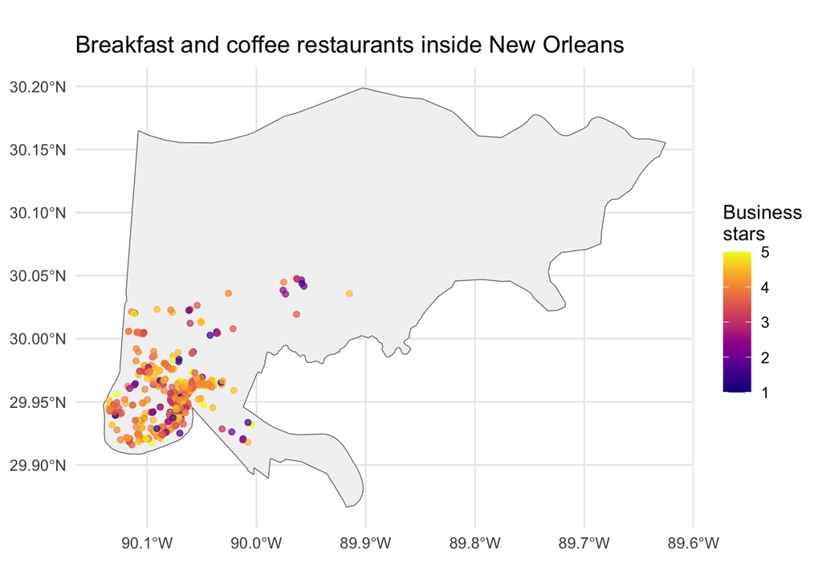

```r
ggplot() +
  geom_sf(data = new_orleans_boundary, fill = "grey95", color = "grey35") +
  geom_sf(data = in_city, aes(color = stars), alpha = 0.7, size = 1.4) +
  scale_color_viridis_c(option = "C", limits = c(1, 5)) +
  labs(title = "Breakfast and coffee restaurants inside New Orleans", color = "Business\nstars")
```

```r
ggsave("figures/restaurants_in_new_orleans.png", width = 8, height = 6, dpi = 150, bg = "white")
```

## Step 6: Compare and choose a geographic system

I compared two Census geographies:

- **ZIP Code Tabulation Areas (ZCTAs):** postal-style areas that most readers recognise.
- **Census tracts (Orleans Parish):** statistical areas of roughly 1,200-8,000 people.

I did not use Neighborhood Statistical Areas or wards. Both are available from Data.NOLA.gov but I limited this comparison to systems available directly through `tigris`.

```r
zcta <- zctas(year = 2020) |>
  st_transform(4326) |>
  select(area = ZCTA5CE20)

tracts_orleans <- tracts("LA", county = "Orleans", cb = TRUE, year = 2023) |>
  st_transform(4326) |>
  select(area = GEOID)

assign_area <- function(points, boundaries) {
  points |>
    st_join(boundaries, join = st_within, left = TRUE) |>
    st_drop_geometry()
}

by_zcta <- assign_area(in_city, zcta)
by_tract <- assign_area(in_city, tracts_orleans)

area_summary <- function(df) {
  df |>
    filter(!is.na(area)) |>
    group_by(area) |>
    summarise(
      restaurants = n(),
      avg_stars = mean(stars),
      median_stars = median(stars),
      total_yelp_reviews = sum(review_count),
      established = sum(review_count >= 20),
      avg_stars_established = if_else(
        established > 0, mean(stars[review_count >= 20]), NA_real_
      ),
      .groups = "drop"
    )
}

zcta_summary <- area_summary(by_zcta)
tract_summary <- area_summary(by_tract)

geo_comparison <- tibble(
  `Geographic system` = c("ZIP/ZCTA", "Census tract"),
  `Areas with a restaurant` = c(nrow(zcta_summary), nrow(tract_summary)),
  `Restaurants assigned` = c(sum(zcta_summary$restaurants), sum(tract_summary$restaurants)),
  `Unmatched restaurants` = c(sum(is.na(by_zcta$area)), sum(is.na(by_tract$area))),
  `Smallest area count` = c(min(zcta_summary$restaurants), min(tract_summary$restaurants)),
  `Median area count` = c(median(zcta_summary$restaurants), median(tract_summary$restaurants)),
  `Largest area count` = c(max(zcta_summary$restaurants), max(tract_summary$restaurants)),
  `Areas with fewer than 5` = c(sum(zcta_summary$restaurants < 5), sum(tract_summary$restaurants < 5))
)

knitr::kable(geo_comparison, caption = "Comparison of geographic systems (restaurants inside New Orleans)")
```

Comparison of geographic systems (restaurants inside New Orleans)

| Geographic system | Areas with a restaurant | Restaurants assigned | Unmatched restaurants | Smallest area count | Median area count | Largest area count | Areas with fewer than 5 |
| --- | --- | --- | --- | --- | --- | --- | --- |
| ZIP/ZCTA | 18 | 564 | 0 | 1 | 14 | 146 | 3 |
| Census tract | 103 | 564 | 0 | 1 | 2 | 117 | 75 |

**Evidence for the Step 3 requirement (10+ restaurants in 7+ areas):** the 564 selected restaurants fall in 18 different ZIP areas, and 11 of those ZIP areas have 10 or more of them. The requirement is met under ZIP codes (and under census tracts, which use 103 areas).

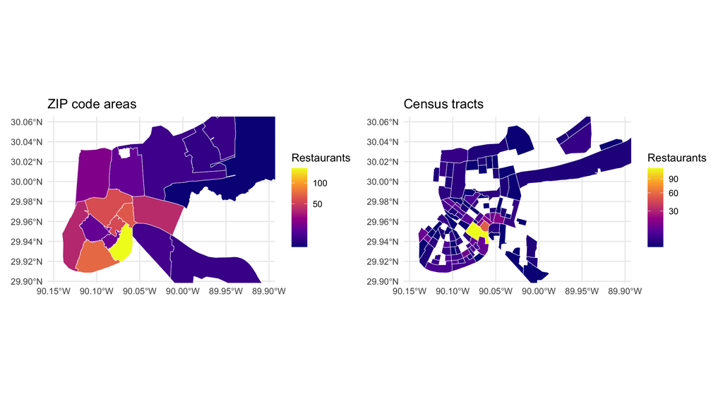

```r
# zoom to where the restaurants are; the official city boundary includes miles of marsh and water
focus <- st_bbox(in_city) + c(-0.01, -0.01, 0.01, 0.01)

make_map <- function(boundaries, summary, title) {
  boundaries |>
    inner_join(summary, by = "area") |>
    ggplot() +
    geom_sf(aes(fill = restaurants), color = "white", linewidth = 0.2) +
    scale_fill_viridis_c(option = "C", trans = "sqrt") +
    coord_sf(xlim = focus[c("xmin", "xmax")], ylim = focus[c("ymin", "ymax")]) +
    labs(title = title, fill = "Restaurants")
}

p_zcta <- make_map(zcta, zcta_summary, "ZIP code areas")
p_tract <- make_map(tracts_orleans, tract_summary, "Census tracts")

gridExtra_ok <- requireNamespace("patchwork", quietly = TRUE)
if (gridExtra_ok) {
  patchwork::wrap_plots(p_zcta, p_tract, nrow = 1)
} else {
  print(p_zcta); print(p_tract)
}
```

```r
ggsave("figures/geography_comparison_counts.png", width = 11, height = 6, dpi = 150, bg = "white")
```

```r
zcta_summary |>
  arrange(desc(restaurants)) |>
  mutate(across(c(avg_stars, median_stars, avg_stars_established), \(x) round(x, 2))) |>
  knitr::kable(caption = "Breakfast and coffee restaurants by ZIP code area")
```

Breakfast and coffee restaurants by ZIP code area

| area | restaurants | avg_stars | median_stars | total_yelp_reviews | established | avg_stars_established |
| --- | --- | --- | --- | --- | --- | --- |
| 70130 | 146 | 3.76 | 4.00 | 76893 | 120 | 3.85 |
| 70115 | 72 | 4.01 | 4.00 | 14117 | 67 | 3.99 |
| 70116 | 64 | 3.97 | 4.00 | 21364 | 47 | 3.96 |
| 70119 | 58 | 3.83 | 4.00 | 10510 | 49 | 3.89 |
| 70112 | 56 | 3.64 | 3.75 | 10118 | 39 | 3.85 |
| 70117 | 40 | 4.11 | 4.50 | 7253 | 33 | 4.15 |
| 70118 | 38 | 3.82 | 4.00 | 6385 | 32 | 3.84 |
| 70124 | 20 | 3.80 | 4.00 | 3040 | 18 | 3.81 |
| 70113 | 15 | 3.97 | 4.00 | 2937 | 9 | 4.28 |
| 70122 | 13 | 3.50 | 3.50 | 688 | 10 | 3.65 |
| 70125 | 13 | 3.38 | 3.50 | 812 | 11 | 3.18 |
| 70114 | 7 | 3.93 | 4.50 | 406 | 7 | 3.93 |
| 70126 | 6 | 2.67 | 2.50 | 286 | 5 | 2.90 |
| 70128 | 5 | 2.30 | 2.00 | 123 | 3 | 2.17 |
| 70131 | 5 | 3.10 | 2.50 | 230 | 2 | 3.25 |
| 70127 | 4 | 3.12 | 3.00 | 73 | 2 | 3.25 |
| 70129 | 1 | 4.50 | 4.50 | 402 | 1 | 4.50 |
| 70139 | 1 | 3.00 | 3.00 | 13 | 0 | NA |

### Which area is best?

An area is only fairly comparable if it has several restaurants with enough reviews to trust. I rank areas by the average stars of **established restaurants (at least 20 Yelp reviews)**, and only count areas with at least 5 established restaurants.

```r
min_established <- 5

best_areas <- zcta_summary |>
  filter(established >= min_established) |>
  arrange(desc(avg_stars_established)) |>
  select(ZIP = area, restaurants, established, avg_stars_established, total_yelp_reviews)

best_areas |>
  mutate(avg_stars_established = round(avg_stars_established, 2)) |>
  knitr::kable(caption = "ZIP areas ranked by average stars of established restaurants (5+ established restaurants required)")
```

ZIP areas ranked by average stars of established restaurants (5+ established restaurants required)

| ZIP | restaurants | established | avg_stars_established | total_yelp_reviews |
| --- | --- | --- | --- | --- |
| 70113 | 15 | 9 | 4.28 | 2937 |
| 70117 | 40 | 33 | 4.15 | 7253 |
| 70115 | 72 | 67 | 3.99 | 14117 |
| 70116 | 64 | 47 | 3.96 | 21364 |
| 70114 | 7 | 7 | 3.93 | 406 |
| 70119 | 58 | 49 | 3.89 | 10510 |
| 70112 | 56 | 39 | 3.85 | 10118 |
| 70130 | 146 | 120 | 3.85 | 76893 |
| 70118 | 38 | 32 | 3.84 | 6385 |
| 70124 | 20 | 18 | 3.81 | 3040 |
| 70122 | 13 | 10 | 3.65 | 688 |
| 70125 | 13 | 11 | 3.18 | 812 |
| 70126 | 6 | 5 | 2.90 | 286 |

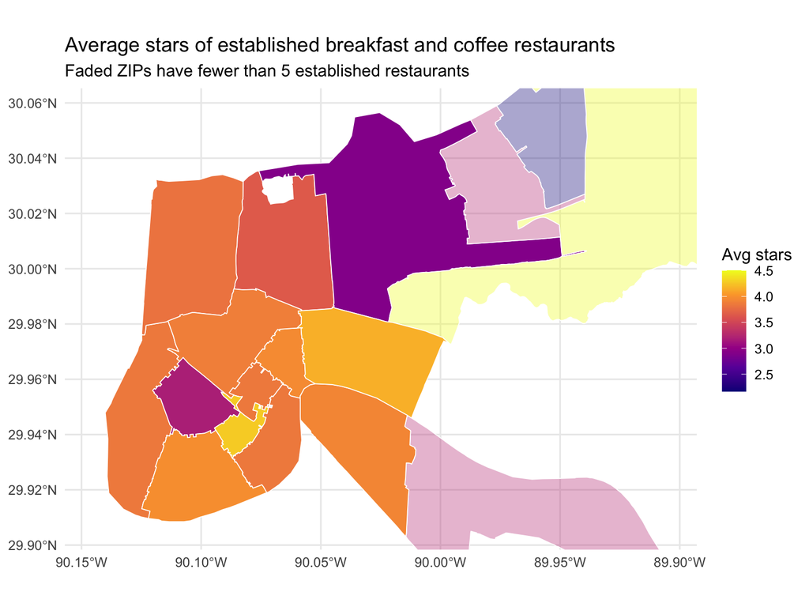

```r
zcta |>
  inner_join(zcta_summary, by = "area") |>
  mutate(rankable = established >= min_established) |>
  ggplot() +
  geom_sf(aes(fill = avg_stars_established, alpha = rankable), color = "white", linewidth = 0.3) +
  scale_fill_viridis_c(option = "C", na.value = "grey85") +
  scale_alpha_manual(values = c(`TRUE` = 1, `FALSE` = 0.35), guide = "none") +
  coord_sf(xlim = focus[c("xmin", "xmax")], ylim = focus[c("ymin", "ymax")]) +
  labs(
    title = "Average stars of established breakfast and coffee restaurants",
    subtitle = "Faded ZIPs have fewer than 5 established restaurants",
    fill = "Avg stars"
  )
```

```r
ggsave("figures/zip_ratings_map.png", width = 8, height = 6, dpi = 150, bg = "white")
```

### Decision

**Geographic system: ZIP code areas (ZCTAs).**

- **Enough restaurants per area.** The restaurants fall into 18 ZIP areas (median 14 restaurants per area, only 3 areas with fewer than 5) but 103 census tracts (median 2 per tract, 75 tracts with fewer than 5). Tract averages would rest on one or two restaurants, so they are too noisy to rank.
- **No unmatched points.** Both systems assign every restaurant inside the city, so matching was not a deciding factor.
- **Understandable to readers.** People looking for a place to eat already think in ZIP codes; tract numbers mean nothing to most readers.
- **What ZIPs hide.** ZIP areas are postal units, not neighborhoods, and the large ZIP (70130, the CBD/Warehouse District area) mixes very different blocks. The tract map shows that the restaurants in a ZIP are often concentrated in one corner of it.

**Which area is best?** Two ZIPs lead on average stars among established restaurants.

- **70113** (Central City / Garden District area, approximate) has the highest average, 4.28, but only 9 established restaurants.
- **70117** (Bywater / Marigny / St. Roch area) is close behind at 4.15 with 33 established restaurants out of 40 breakfast and coffee places, and 7,253 Yelp reviews.

Because 70117’s average rests on more than three times as many established restaurants, I consider it the **best area for finding breakfast and coffee**, with 70113 a strong but thinner runner-up. The French Quarter/CBD ZIP, 70130, has by far the most choices (146 restaurants, about 77,000 Yelp reviews) but an average of only 3.85, so it is best for variety rather than for quality. ZIP names above are approximate.

## Step 7: Raw ratings vs. reviewer-adjusted scores

Some reviewers give nearly everything five stars and others rarely do. To account for that I compare each rating with the reviewer’s own usual rating.

- **Reviewers with enough history:** reviewers with at least **5 reviews** of the breakfast and coffee restaurants inside New Orleans.
- **Baseline:** each reviewer’s **mean** star rating across those restaurants. I chose the mean over the median because star ratings are whole numbers, so a median is too coarse (it is almost always 4 or 5).
- **Normalized score:** the rating minus the reviewer’s mean. A reviewer who averages 5 and gives 5 stars scores 0; one who averages 3 and gives 4 stars scores +1. This is not a new Yelp rating; it only says whether a review was above or below that reviewer’s usual.

```r
city_ids <- in_city$business_id

category_reviews <- selected_reviews |>
  filter(business_id %in% city_ids)

reviewer_baselines <- category_reviews |>
  group_by(user_id) |>
  summarise(
    reviewer_mean = mean(stars),
    reviewer_review_count = n(),
    .groups = "drop"
  )

adjusted_reviews <- function(min_reviews) {
  category_reviews |>
    inner_join(
      reviewer_baselines |> filter(reviewer_review_count >= min_reviews),
      by = "user_id"
    ) |>
    mutate(normalized_score = stars - reviewer_mean)
}

eligible_reviews <- adjusted_reviews(5)

tibble(
  all_reviews = nrow(category_reviews),
  all_reviewers = nrow(reviewer_baselines),
  eligible_reviewers = n_distinct(eligible_reviews$user_id),
  share_of_reviewers = percent(n_distinct(eligible_reviews$user_id) / nrow(reviewer_baselines), 0.1),
  eligible_reviews = nrow(eligible_reviews),
  share_of_reviews = percent(nrow(eligible_reviews) / nrow(category_reviews), 0.1)
) |>
  knitr::kable(caption = "Reviewers with at least 5 reviews")
```

Reviewers with at least 5 reviews

[output not shown]

```r
min_eligible <- 20

restaurant_summary <- in_city |>
  st_drop_geometry() |>
  select(business_id, business_name, yelp_stars = stars) |>
  left_join(by_zcta |> select(business_id, area), by = "business_id") |>
  left_join(
    category_reviews |>
      group_by(business_id) |>
      summarise(
        reviews_all = n(),
        avg_stars_all = mean(stars),
        .groups = "drop"
      ),
    by = "business_id"
  ) |>
  left_join(
    eligible_reviews |>
      group_by(business_id) |>
      summarise(
        reviews_eligible = n(),
        avg_stars_eligible = mean(stars),
        avg_normalized = mean(normalized_score),
        .groups = "drop"
      ),
    by = "business_id"
  )

ranked <- restaurant_summary |>
  filter(reviews_eligible >= min_eligible) |>
  mutate(
    rank_raw = rank(-avg_stars_all, ties.method = "min"),
    rank_adjusted = rank(-avg_normalized, ties.method = "min"),
    rank_change = rank_raw - rank_adjusted
  )

tibble(
  restaurants_in_city = nrow(restaurant_summary),
  with_20_plus_eligible_reviews = nrow(ranked),
  rank_correlation_raw_vs_adjusted = round(cor(ranked$avg_stars_all, ranked$avg_normalized, method = "spearman"), 2)
) |>
  knitr::kable(caption = "Restaurants ranked (20+ eligible reviews)")
```

Restaurants ranked (20+ eligible reviews)

| restaurants_in_city | with_20_plus_eligible_reviews | rank_correlation_raw_vs_adjusted |
| --- | --- | --- |
| 564 | 304 | 0.86 |

### Does the threshold matter?

```r
top10_at <- function(min_reviews) {
  adjusted_reviews(min_reviews) |>
    group_by(business_id) |>
    summarise(n = n(), adj = mean(normalized_score), .groups = "drop") |>
    filter(n >= min_eligible) |>
    slice_max(adj, n = 10, with_ties = FALSE) |>
    pull(business_id)
}

top10_base <- top10_at(5)

threshold_table <- map_dfr(c(3, 5, 10), \(k) {
  r <- adjusted_reviews(k)
  tibble(
    `Minimum reviews per reviewer` = k,
    `Reviewers kept` = n_distinct(r$user_id),
    `Share of all reviews` = percent(nrow(r) / nrow(category_reviews), 0.1),
    `Restaurants with 20+ eligible reviews` = r |> count(business_id) |> filter(n >= min_eligible) |> nrow(),
    `Top-10 overlap with the 5-review top 10` = length(intersect(top10_at(k), top10_base))
  )
})

knitr::kable(threshold_table, caption = "Changing the reviewer threshold")
```

Changing the reviewer threshold

| Minimum reviews per reviewer | Reviewers kept | Share of all reviews | Restaurants with 20+ eligible reviews | Top-10 overlap with the 5-review top 10 |
| --- | --- | --- | --- | --- |
| 3 | 11474 | 36.0% | 368 | 5 |
| 5 | 3398 | 19.3% | 304 | 10 |
| 10 | 780 | 9.3% | 222 | 5 |

### Which restaurants move most?

```r
ranked |>
  arrange(desc(avg_normalized)) |>
  slice_head(n = 10) |>
  transmute(
    Restaurant = business_name, ZIP = area,
    `Raw avg stars` = round(avg_stars_all, 2),
    `Adjusted score` = round(avg_normalized, 2),
    `Eligible reviews` = reviews_eligible,
    `Raw rank` = rank_raw, `Adjusted rank` = rank_adjusted
  ) |>
  knitr::kable(caption = "Top 10 by reviewer-adjusted score (20+ eligible reviews)")
```

Top 10 by reviewer-adjusted score (20+ eligible reviews)

| Restaurant | ZIP | Raw avg stars | Adjusted score | Eligible reviews | Raw rank | Adjusted rank |
| --- | --- | --- | --- | --- | --- | --- |
| Park Island Brew | 70119 | 4.85 | 0.62 | 24 | 1 | 1 |
| Angelo Brocato | 70119 | 4.67 | 0.61 | 284 | 9 | 2 |
| Coffee Science | 70119 | 4.70 | 0.54 | 37 | 6 | 3 |
| Piccola Gelateria | 70115 | 4.73 | 0.51 | 97 | 4 | 4 |
| Paladar 511 | 70117 | 4.52 | 0.45 | 158 | 26 | 5 |
| Sólo Espresso | 70117 | 4.66 | 0.43 | 25 | 11 | 6 |
| Welty’s Deli and Catering | 70130 | 4.67 | 0.43 | 95 | 8 | 7 |
| Dong Phuong | 70129 | 4.33 | 0.43 | 156 | 70 | 8 |
| Fatma’s Cozy Corner | 70116 | 4.74 | 0.42 | 24 | 2 | 9 |
| Two Chicks Café - CBD | 70112 | 4.59 | 0.42 | 35 | 19 | 10 |

```r
bind_rows(
  ranked |> slice_max(rank_change, n = 5, with_ties = FALSE),
  ranked |> slice_min(rank_change, n = 5, with_ties = FALSE)
) |>
  transmute(
    Restaurant = business_name, ZIP = area,
    `Raw avg stars` = round(avg_stars_all, 2),
    `Adjusted score` = round(avg_normalized, 2),
    `Raw rank` = rank_raw, `Adjusted rank` = rank_adjusted,
    `Places gained` = rank_change
  ) |>
  knitr::kable(caption = "Largest rank changes after adjustment (positive = moved up)")
```

Largest rank changes after adjustment (positive = moved up)

| Restaurant | ZIP | Raw avg stars | Adjusted score | Raw rank | Adjusted rank | Places gained |
| --- | --- | --- | --- | --- | --- | --- |
| Le Citron Bistro | 70130 | 3.81 | 0.35 | 208 | 25 | 183 |
| Starbucks | 70130 | 3.15 | 0.01 | 290 | 148 | 142 |
| Little Vic’s | 70130 | 3.99 | 0.35 | 163 | 23 | 140 |
| La Boulangerie | 70115 | 4.10 | 0.37 | 141 | 15 | 126 |
| Pho Tau Bay Restaurant | 70112 | 3.90 | 0.19 | 193 | 86 | 107 |
| Wakin’ Bakin’ | 70115 | 4.23 | -0.30 | 99 | 240 | -141 |
| Gallier Restaurant & Oyster Bar | 70130 | 4.29 | -0.22 | 85 | 223 | -138 |
| La Macarena Pupuseria & Latin Cafe | 70118 | 4.20 | -0.28 | 106 | 236 | -130 |
| Catalino’s | 70118 | 4.73 | 0.07 | 3 | 127 | -124 |
| Two Chicks Cafe | 70130 | 4.45 | 0.02 | 41 | 139 | -98 |

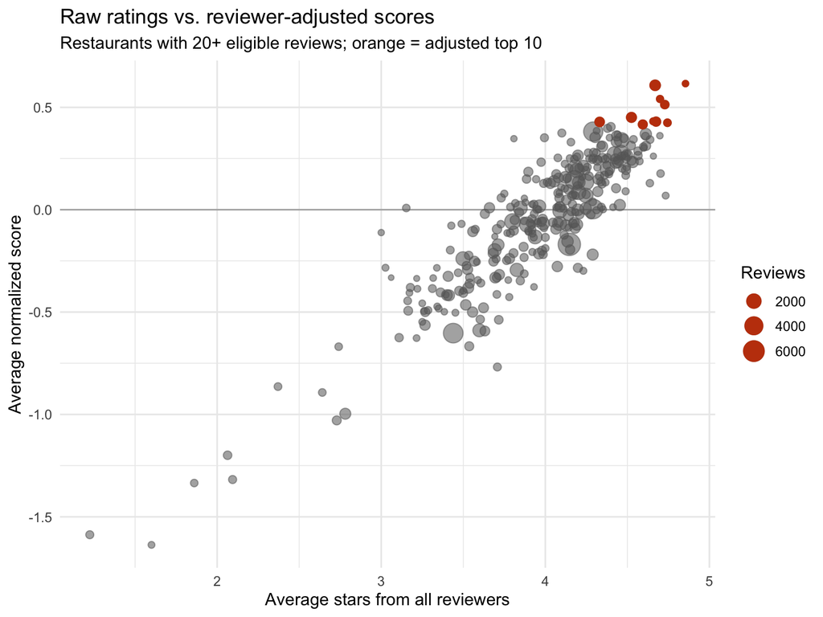

```r
top10 <- ranked |> slice_max(avg_normalized, n = 10, with_ties = FALSE)

ggplot(ranked, aes(avg_stars_all, avg_normalized)) +
  geom_hline(yintercept = 0, color = "grey70") +
  geom_point(aes(size = reviews_all), alpha = 0.55, color = "grey40") +
  geom_point(data = top10, aes(size = reviews_all), color = "#c2410c") +
  scale_size_continuous(range = c(1.5, 7)) +
  labs(
    title = "Raw ratings vs. reviewer-adjusted scores",
    subtitle = "Restaurants with 20+ eligible reviews; orange = adjusted top 10",
    x = "Average stars from all reviewers", y = "Average normalized score", size = "Reviews"
  )
```

```r
ggsave("figures/raw_vs_adjusted.png", width = 8, height = 6, dpi = 150, bg = "white")
```

### Do the best areas change?

```r
zip_adjusted <- eligible_reviews |>
  left_join(by_zcta |> select(business_id, area), by = "business_id") |>
  filter(!is.na(area)) |>
  group_by(area) |>
  summarise(
    eligible_reviews = n(),
    avg_normalized = mean(normalized_score),
    .groups = "drop"
  ) |>
  left_join(
    ranked |>
      group_by(area) |>
      summarise(
        restaurants_20plus = n(),
        avg_stars_ranked = mean(avg_stars_all),
        .groups = "drop"
      ),
    by = "area"
  ) |>
  filter(coalesce(restaurants_20plus, 0L) >= min_established)

zip_table <- zip_adjusted |>
  mutate(rank_raw = rank(-avg_stars_ranked), rank_adjusted = rank(-avg_normalized)) |>
  arrange(rank_adjusted) |>
  transmute(
    ZIP = area, `Restaurants (20+ eligible)` = restaurants_20plus,
    `Raw avg stars` = round(avg_stars_ranked, 2),
    `Adjusted score` = round(avg_normalized, 3),
    `Raw rank` = rank_raw, `Adjusted rank` = rank_adjusted
  )

knitr::kable(zip_table, caption = "ZIP areas with 5+ restaurants that have 20+ eligible reviews")
```

ZIP areas with 5+ restaurants that have 20+ eligible reviews

| ZIP | Restaurants (20+ eligible) | Raw avg stars | Adjusted score | Raw rank | Adjusted rank |
| --- | --- | --- | --- | --- | --- |
| 70117 | 21 | 4.15 | 0.107 | 1 | 1 |
| 70119 | 34 | 4.07 | 0.094 | 2 | 2 |
| 70115 | 51 | 4.04 | 0.094 | 3 | 3 |
| 70112 | 24 | 3.97 | -0.028 | 4 | 4 |
| 70118 | 29 | 3.87 | -0.033 | 7 | 5 |
| 70116 | 35 | 3.93 | -0.038 | 5 | 6 |
| 70130 | 80 | 3.90 | -0.049 | 6 | 7 |
| 70125 | 6 | 3.69 | -0.135 | 8 | 8 |
| 70124 | 13 | 3.65 | -0.189 | 9 | 9 |

```r
# Does the ZIP-level ranking survive a different reviewer cutoff?
zip_rank_at <- function(min_reviews) {
  r <- adjusted_reviews(min_reviews)
  eligible_restaurants <- r |> count(business_id) |> filter(n >= min_eligible)
  r |>
    left_join(by_zcta |> select(business_id, area), by = "business_id") |>
    filter(!is.na(area)) |>
    group_by(area) |>
    summarise(avg_normalized = mean(normalized_score), .groups = "drop") |>
    left_join(
      eligible_restaurants |>
        left_join(by_zcta |> select(business_id, area), by = "business_id") |>
        count(area, name = "restaurants_20plus"),
      by = "area"
    ) |>
    filter(coalesce(restaurants_20plus, 0L) >= min_established) |>
    arrange(desc(avg_normalized)) |>
    mutate(rank = row_number()) |>
    select(area, rank)
}

zip_threshold_table <- map(c(3, 5, 10), \(k) zip_rank_at(k) |> rename_with(\(x) paste0("rank_", k), rank)) |>
  reduce(full_join, by = "area") |>
  arrange(rank_5)

knitr::kable(zip_threshold_table, caption = "ZIP rank (by adjusted score) at three reviewer cutoffs; blank = fewer than 5 restaurants with 20+ eligible reviews")
```

ZIP rank (by adjusted score) at three reviewer cutoffs; blank = fewer than 5 restaurants with 20+ eligible reviews

| area | rank_3 | rank_5 | rank_10 |
| --- | --- | --- | --- |
| 70117 | 3 | 1 | 2 |
| 70119 | 4 | 2 | 3 |
| 70115 | 2 | 3 | 1 |
| 70112 | 9 | 4 | 5 |
| 70118 | 5 | 5 | 7 |
| 70116 | 6 | 6 | 4 |
| 70130 | 7 | 7 | 6 |
| 70125 | 10 | 8 | NA |
| 70124 | 11 | 9 | 8 |
| 70113 | 1 | NA | NA |
| 70122 | 8 | NA | NA |

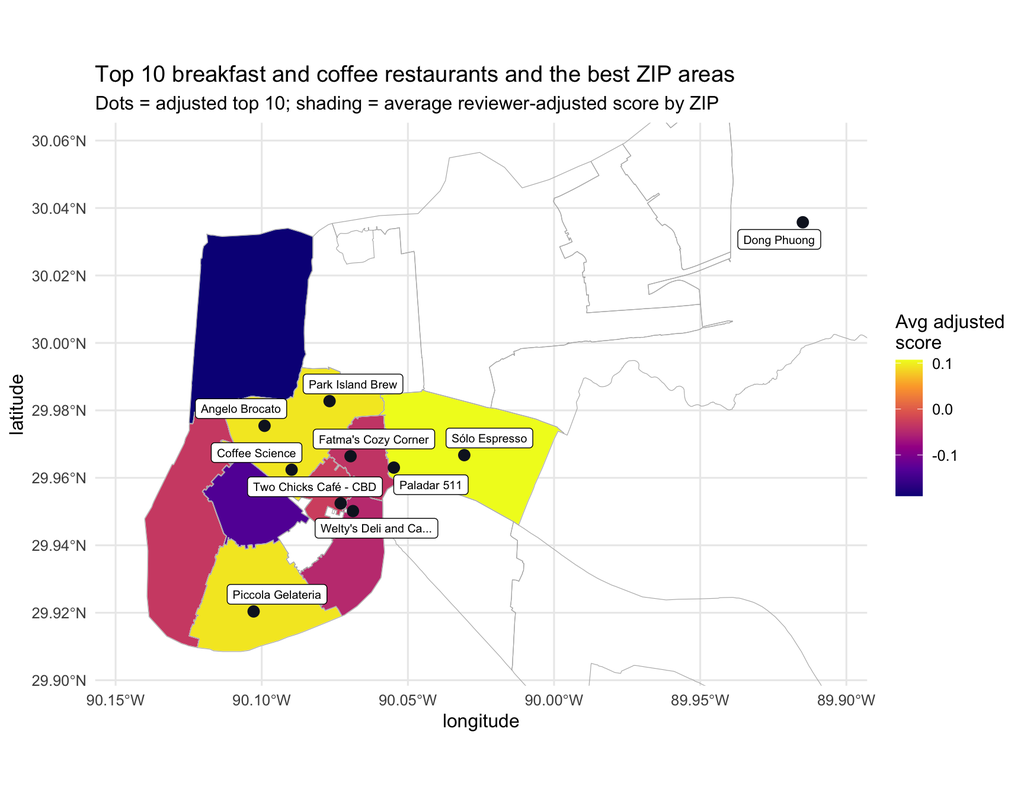

```r
top10_points <- in_city |> semi_join(top10, by = "business_id")

ggplot() +
  geom_sf(
    data = zcta |> inner_join(zip_adjusted, by = "area"),
    aes(fill = avg_normalized), color = "white", linewidth = 0.3
  ) +
  geom_sf(data = zcta |> filter(area %in% zcta_summary$area), fill = NA, color = "grey70", linewidth = 0.2) +
  geom_sf(data = top10_points, color = "#111827", size = 3) +
  ggrepel::geom_label_repel(
    data = top10_points |>
      mutate(label = str_trunc(business_name, 22)) |>
      st_drop_geometry(),
    aes(x = longitude, y = latitude, label = label), size = 2.6, max.overlaps = Inf
  ) +
  scale_fill_viridis_c(option = "C", name = "Avg adjusted\nscore") +
  coord_sf(xlim = focus[c("xmin", "xmax")], ylim = focus[c("ymin", "ymax")]) +
  labs(
    title = "Top 10 breakfast and coffee restaurants and the best ZIP areas",
    subtitle = "Dots = adjusted top 10; shading = average reviewer-adjusted score by ZIP"
  )
```

```r
ggsave("figures/top10_map.png", width = 9, height = 7, dpi = 150, bg = "white")
```

```r
# tables reused by summary.qmd (the short PDF report)
dir.create("results", showWarnings = FALSE)
write.csv(geo_comparison, "results/geography_comparison.csv", row.names = FALSE)
write.csv(threshold_table, "results/threshold_table.csv", row.names = FALSE)
write.csv(zip_table, "results/zip_adjusted.csv", row.names = FALSE)
write.csv(
  ranked |>
    slice_max(avg_normalized, n = 10, with_ties = FALSE) |>
    transmute(rank = row_number(), restaurant = business_name, zip = area,
              raw_stars = round(avg_stars_all, 2), adjusted = round(avg_normalized, 2),
              eligible_reviews = reviews_eligible, raw_rank = rank_raw),
  "results/top10.csv", row.names = FALSE
)
write.csv(
  tibble(
    restaurants_in_city = nrow(restaurant_summary),
    all_reviews = nrow(category_reviews),
    all_reviewers = nrow(reviewer_baselines),
    eligible_reviewers = n_distinct(eligible_reviews$user_id),
    eligible_reviews = nrow(eligible_reviews),
    ranked_restaurants = nrow(ranked),
    rank_correlation = cor(ranked$avg_stars_all, ranked$avg_normalized, method = "spearman")
  ),
  "results/key_numbers.csv", row.names = FALSE
)
```

### Final answer

**Best area: ZIP 70117 (Bywater / Marigny / St. Roch area) at my main settings, but really a group of three.** It is first on raw stars (4.15) and first after adjustment at the 5-review cutoff. But the margin is small: 70119 (Mid-City) and 70115 (Uptown) are about 0.01 behind, and the order changes with the cutoff (70117 is 1st at 5 reviews, 2nd at 10 and 3rd at 3; see the ZIP-rank table above). What does hold is that 70117, 70115 and 70119 are the top three at cutoffs 5 and 10, and among the top four at cutoff 3. So the defensible conclusion is that these three ZIPs are the best areas, with 70117 first under my chosen settings. The French Quarter and downtown ZIPs (70116, 70112, 70130) have the most restaurants but fall below zero on the adjusted score, meaning their reviewers rate them slightly lower than those same reviewers’ usual.

**Top 10 restaurants** (adjusted score, 20+ eligible reviews): Park Island Brew, Angelo Brocato, Coffee Science, Piccola Gelateria, Paladar 511, Sólo Espresso, Welty’s Deli and Catering, Dong Phuong, Fatma’s Cozy Corner and Two Chicks Café - CBD. Three are in 70119 and two in 70117.

**What the adjustment changed.**

- Overall the two rankings agree (rank correlation 0.86), but individual restaurants move a lot. Dong Phuong jumps from raw rank 70 to 8 and Paladar 511 from 26 to 5, because their reviewers usually rate other places lower. Catalino’s falls from 3 to 127: its 4.73 raw average comes from reviewers who give nearly everyone high ratings.
- Some of the largest moves are likely noise rather than reviewer behavior. Several top-10 places have only 24 to 37 eligible reviews, and the 5-review baseline is itself a rough estimate.
- The top 10 is **not stable** to the threshold. Using 3 or 10 reviews instead of 5 keeps only 5 of the 10 restaurants. The ZIP ranking also shifts (see the ZIP-rank table above), but the same three ZIPs stay at the top while the restaurant list changes by half. I therefore state the area result as a group of three ZIPs and treat the top 10 as strong contenders, not a firm ranking.

## Limitations

- Yelp ratings come from self-selected reviewers, so a restaurant’s rating reflects who chose to review it, not every diner.
- The reviewer baseline is based on only a handful of reviews for most reviewers (5 or more), so it is a rough estimate of their habits and includes the review being adjusted.
- The baseline is built only from each reviewer’s reviews of these New Orleans breakfast and coffee restaurants, not their ratings across all of Yelp. A reviewer who mostly rates in other cities or cuisines gets a baseline from a few local reviews.
- The Yelp dataset is a snapshot, so closed restaurants and changed ratings are not reflected.
- ZIP areas are postal units, not neighborhoods, and tracts are very small. Neighborhood Statistical Areas and wards from Data.NOLA.gov were not tested.
- Some Yelp coordinates look wrong (for example Le Petit Bistro, which has no street address).

## AI prompts used

These are the prompts I used while building Step 7 and writing it up, quoted as I wrote them. Each one maps to a part of the report.

### 1. Building the reviewer-adjusted score (Step 7 code)

> In my New Orleans breakfast/coffee project, I want to rank restaurants by a reviewer-adjusted score, not raw stars. The idea is: for each reviewer with at least 5 reviews, compute their average star rating; then for each review, subtract that reviewer’s average from the stars they gave; then average those adjusted values per restaurant, keeping only restaurants with 20+ eligible reviews. Can you write the pipeline for this and explain what each step does?

Used for: the `reviewer_baselines`, `adjusted_reviews()` and `restaurant_summary` chunks.

**Follow-up I asked:** “The 5-review thresholds are hard-coded in two places. Can you make both cutoffs function arguments so I can rerun the whole pipeline at 3 and 10 without editing the body?”

**What changed:** The reviewer cutoff is now a function argument (`adjusted_reviews(min_reviews)`, reused by `top10_at()`), so the 3/5/10 comparison is one call each instead of copy-pasting the chunk. The restaurant cutoff (20 eligible reviews) is a single variable, `min_eligible`, set once, rather than a function argument. I also keep the all-reviewer average (`avg_stars_all`) separate from the eligible-reviewer average (`avg_stars_eligible`), so the “Raw avg stars” column is the all-reviewers number and not a quietly different quantity.

### 2. Making sure I understand the code I submit

> I have this chunk in my Quarto file and I want to be able to explain it in my write-up. Can you walk through it line by line and tell me what inner_join and mutate are doing here, and why the inner_join matters for which reviews survive?

Used for: the explanation of how only reviews from eligible reviewers (5+ reviews) are kept.

**Follow-up I asked:** “My reviewer baseline is computed after I’ve already filtered the reviews down to New Orleans. So it’s each reviewer’s average in New Orleans, not their average across all of Yelp. Does that change what the baseline means, and should I say so in the limitations?”

**What changed:** The first explanation covered `inner_join` and `mutate` but did not flag that the baseline (`reviewer_mean`) comes from a filtered review set. In my code it is narrower still: only reviews of the breakfast and coffee restaurants inside the city boundary. I added that to the limitations instead of implying a Yelp-wide baseline.

### 3. Explaining the results in plain language

> I need to explain in plain language what a reviewer-adjusted score of +0.62 means for a restaurant, and why the raw and adjusted rankings mostly agree (rank correlation 0.86) but some restaurants move dramatically. Can you explain the concept and give a concrete example from my results?

Used for: the “What the adjustment changed” discussion (for example Dong Phuong moving from #70 to #8).

**Follow-up I asked:** “Can I add +0.62 to the raw 4.85 to get an ‘effective’ rating of about 5.47? Or is the adjusted score on a different scale?”

**What changed:** My first draft called it an “effective rating”, which is wrong: the adjusted score is relative to each reviewer’s own baseline and is not on the stars scale (4.85 + 0.62 > 5 is the giveaway). The report now says reviewers rated the place about 0.62 stars above their usual, not that it “is” a higher-rated restaurant.

### 4. Checking that my conclusions are consistent

> My report says ZIP codes are the right geographic unit and also that the top-10 restaurant ranking isn’t very stable. Can you explain how those two claims fit together, why the top-10 changes when I switch the review cutoff from 5 to 3 or 10, and what that means for how I should state my conclusion?

Used for: the final answer and the stability section.

**Follow-up I asked:** “You said the top-10 isn’t stable at cutoffs of 3 and 10. Does the ZIP-level ranking also change, or only the restaurant order? I need to know whether my headline claim survives or just the detail.”

**What changed:** I had only tested the restaurant list, so I ran the ZIP ranking at cutoffs 3, 5 and 10 too. It also shifts: 70117 is 1st at 5 reviews, 2nd at 10 and 3rd at 3. What holds is that 70117, 70115 and 70119 stay near the top (top 3 at 5 and 10 reviews, top 4 at 3). I corrected an earlier sentence that called the ZIP result steadier, and now state the finding as a group of three ZIPs, with the top 10 as strong contenders rather than a ranking.